# Assignment 7 Data Wrangling

Yaniv Bronshtein

3/17/2021

**Import the necessary libraries**

```r
library(tidyverse)
library(rvest)
library(broom)
library(Hmisc)
library(ggrepel)
library(jsonlite)
```

# PROBLEM 1:

**1.From the worldometer webpage** **https://www.worldometers.info/coronavirus/usa/new-jersey/** **extract the county-wise COVID data (total cases, new cases, total deaths and new deaths).** **2.Show a nice graphical representation of the county-wise total cases and** **total deaths in a single plot. Use your imagination and Chapter 3 of R for** **Data Science to come up with an appropriate visual representation.** **3.Identify the top two counties reporting most new cases.**

**Part 1**

```r
url <- "https://www.worldometers.info/coronavirus/usa/new-york/"

worldometer_t <- url %>%
  read_html() %>%
  html_nodes("table") %>%
  html_table(fill = TRUE)
```

**Use yesterday’s coronavirus data for New York State since it is fully updated** **Perform the following steps::** **a). Convert worldometer_t[[2]] which is yesterdays data to a tibble** **b). From this tibble extract only the County, TotalCases, NewCases, TotalDeaths, and NewDeaths** **c). Remove the rows that contain the string Total signifying state totals since we only** **want county-wide data**

```r
county_covid_t <- worldometer_t[[2]] %>%
  as_tibble() %>%
  select(County, TotalCases, NewCases, TotalDeaths, NewDeaths) %>%
  filter(!str_detect(County ,"Total"))
```

**Create a function clean_column that takes in the tibble data and the column to** **clean and returns a numeric vector of the cleaned up column**

```r
clean_column <- function(data, col_name) {
  #Cast data as a tibble and extract the col_name as a vector
  col_vec <- as_tibble(data) %>%
    pull(col_name)

  #Check if the vector is numeric. If not, the data requires processing
  #All commas and + need to be removed, the vector needs to be converted to numeric,
  #and the NA's need to be replaced with 0's
  if (!all.is.numeric(col_vec)) {
    return(
      col_vec %>%
        str_replace_all("[,+]", "") %>%
        as.numeric() %>%
        replace_na(0)
    )
  }
  #If the data is already numeric, only the NA's need to be replaced with 0's
  else {
    return(
      col_vec %>%
        replace_na(0)
    )
  }
}
```

**Call clean_column() on each column of county_covid_t**

```r
total_cases <- clean_column(data = county_covid_t, col_name = "TotalCases")
new_cases <- clean_column(data = county_covid_t, col_name = "NewCases")
total_deaths <- clean_column(data = county_covid_t, col_name = "TotalDeaths")
new_deaths <- clean_column(data = county_covid_t, col_name = "NewDeaths")
```

**Create a tibble from the TotalCases and TotalDeaths called cleaned_total_cases_deaths** **Add a calculated column PercentDeaths that shows the death rate**

```r
cleaned_total_cases_deaths <-
  tibble(TotalCases = total_cases,
         TotalDeaths = total_deaths) %>%
  mutate(PercentDeaths =
           paste0(round((total_deaths / total_cases) * 100, 1), "%"))
```

**Add county data to the cleaned_total_cases_deaths tibble and sort by county**

```r
cleaned_total_cases_deaths <-
  bind_cols(county_covid_t %>% select(County), cleaned_total_cases_deaths) %>%
  arrange(County)
```

**Create a ggplot where the bars represent the total cases and the labels** **represent the death rate for each county** **Use geom_text_repel for the death rate adn title the x labels 90 degrees to prevent overlap**

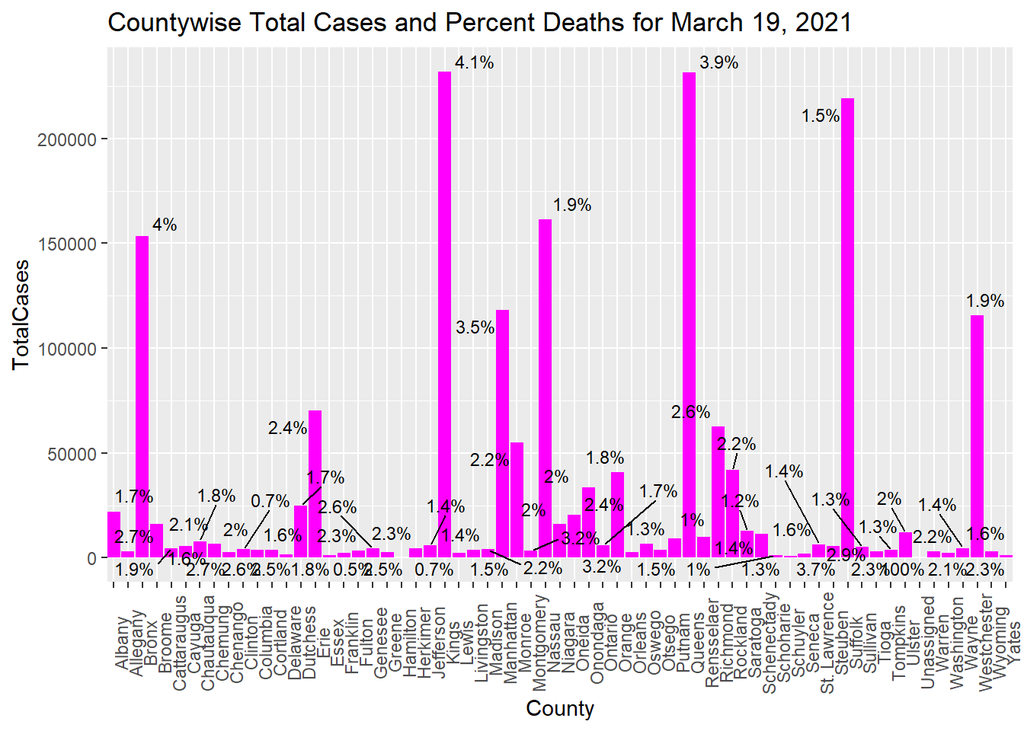

```r
ggplot(data = cleaned_total_cases_deaths,
       mapping = aes(x = County, y = TotalCases)) +
  geom_bar(stat = "identity", fill = "magenta") +
  geom_text_repel(aes(label = PercentDeaths), max.overlaps = 25, size = 3.0) +
  theme(axis.text.x = element_text(angle = 90, hjust = 0.5)) +
  scale_x_discrete(expand = expansion(mult = 0.0)) +
  labs(title = "Countywise Total Cases and Percent Deaths for March 19, 2021")
```

**3.Identify the top two counties reporting most new cases.**

```r
top_2_newcases_counties <-
  tibble(county_covid_t %>% select(County), new_cases) %>%
  arrange(desc(new_cases)) %>%
  head(2)

top_2_newcases_counties
```

```
## # A tibble: 2 x 2
##   County new_cases
##   <chr>      <dbl>
## 1 Kings       1244
## 2 Queens      1211
```

# PROBLEM 2:

**Obtain your free API for https://spoonacular.com/food-api** **Use it to obtain a list of 10 recipes that have carbohydrates not exceeding** **30 grams. Present your output as a 10x3 tibble, where the column names are** **“Recipe” (the title of the recipe), “Carbs” (the carb content) and** **“ID” (the ID of the recipe)** **Find 10 types of Riesling wines whose prices do not exceed $50 and present** **your results as a 10x3 tibble, where the columns** **represent the title of the wine, its ID and its price.**

**Define the API key to be used for both parts**

```r
api_key <-"87c3b12b27b04583b7fe359c409b8fd1"
```

**Construct the url to be used for the recipes**

```r
base_url_recipe <- "https://api.spoonacular.com/recipes/findByNutrients?"
query_recipe <- "maxCarbs=30&number=10&apiKey="
url_recipe <- paste0(base_url_recipe, query_recipe, api_key)
```

**Perform the API call, save the results into a tibble,extracting only the necessary** **columns. Rename the columns to match the names in the problem statement**

```r
json_result_recipe <- url_recipe %>%
  fromJSON()

recipes_t <- json_result_recipe %>%
  as_tibble() %>%
  select(title, carbs, id) %>%
  rename(Recipe = title, Carbs = carbs, ID = id)

recipes_t
```

```
## # A tibble: 10 x 3
##    Recipe                                                           Carbs     ID
##    <chr>                                                            <chr>  <int>
##  1 Anticuchos Of White Seabass With Aji Chile Honey Marinade & Sem~ 0g    632426
##  2 Banana Oatmeal Breakfast Muffins                                 27g   634141
##  3 Gluten Free Dairy Free Sugar Free Chinese Chicken Salad          27g   644826
##  4 Lychee Granita                                                   21g   650499
##  5 Nori Seaweed Muffins                                             27g   653270
##  6 Pumpkin Pie Smoothie                                             22g   657359
##  7 Simple Sage Pesto                                                2g    660130
##  8 Slow Cooked Applesauce                                           16g   660261
##  9 Trinidadian Chicken Potato Curry                                 20g   663824
## 10 Spicy Indian-Style Hummus                                        15g   716195
```

```r
base_url_wine <-"https://api.spoonacular.com/food/wine/recommendation?"
query_wine <- "wine=Riesling&maxPrice=50&number=10&apiKey="
url_wine <- paste0(base_url_wine, query_wine,api_key)
```

**Perform the API call**

```r
json_result_wine <- url_wine %>%
  fromJSON()
```

**Given the more complex output, extract the respective fields directly from the** **the result of fromJSON(). Use successive $ to go deeper** **Create a tibble from the fields requested in the problem statement**

```r
cleaned_wines_t <- tibble(Wine = json_result_wine$recommendedWines$title,
                          ID = json_result_wine$recommendedWines$id,
                          Price = json_result_wine$recommendedWines$price)


cleaned_wines_t
```

```
## # A tibble: 10 x 3
##    Wine                                                           ID Price
##    <chr>                                                       <int> <chr>
##  1 Schloss Johannisberg Rotlack Riesling Kabinett Feinherb    492948 $39.99
##  2 Bollig-Lehnert Piesporter Goldtroopfchen Riesling Spatlese 474522 $23.99
##  3 J.J. Prum Graacher Himmelreich Kabinett Riesling           437965 $21.99
##  4 Alsace Willm Cuvee Emile Willm Riesling                    496530 $22.99
##  5 J.J. Christoffel Erdener Treppchen Riesling Spatlese       461360 $26.99
##  6 Eroica Riesling                                            434655 $23.99
##  7 Fritz Haag Brauneberger Juffer Spatlese Riesling           446064 $29.99
##  8 J.J. Prum Wehlener Sonnenuhr Auslese Riesling              438482 $39.99
##  9 Montinore Estate Almost Dry Riesling                       495768 $15.99
## 10 Fess Parker Rodney's Vineyard Dry Riesling                 501152 $25.99
```